# chapter6.Rmd

# 6.1.11 Drawing a boxplot of the mean weights versus Group

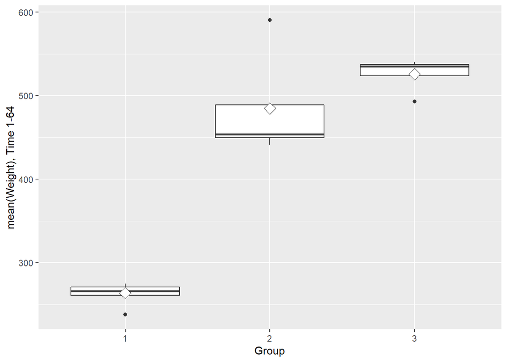

```r
ggplot(RATSL8S, aes(x = Group, y = mean)) +
  geom_boxplot() +
  stat_summary(fun.y = "mean", geom = "point", shape=23, size=4, fill = "white") +
  scale_y_continuous(name = "mean(Weight), Time 1-64")
```

========================================================================================================= Summary measure method was applied by transforming the repeated measurements into a single value that captures some essential feature od the weight gain over time of a rat in each group and taking all time points except the baseline. The diagram indicates that the mean summary measure is more variable in all groups with an outlier in each group =========================================================================================================

# 6.1.12 Creating a new RATS data by filtering the outlier

```r
RATSL8S1 <- RATSL8S %>%
  filter((mean < 300 & mean > 250 & Group ==1)
         |(mean < 550 & Group ==2)
         |(mean > 500 & Group ==3))
```

# 6.1.13 Adjusting the ggplot code and drawing the plot again with the new data

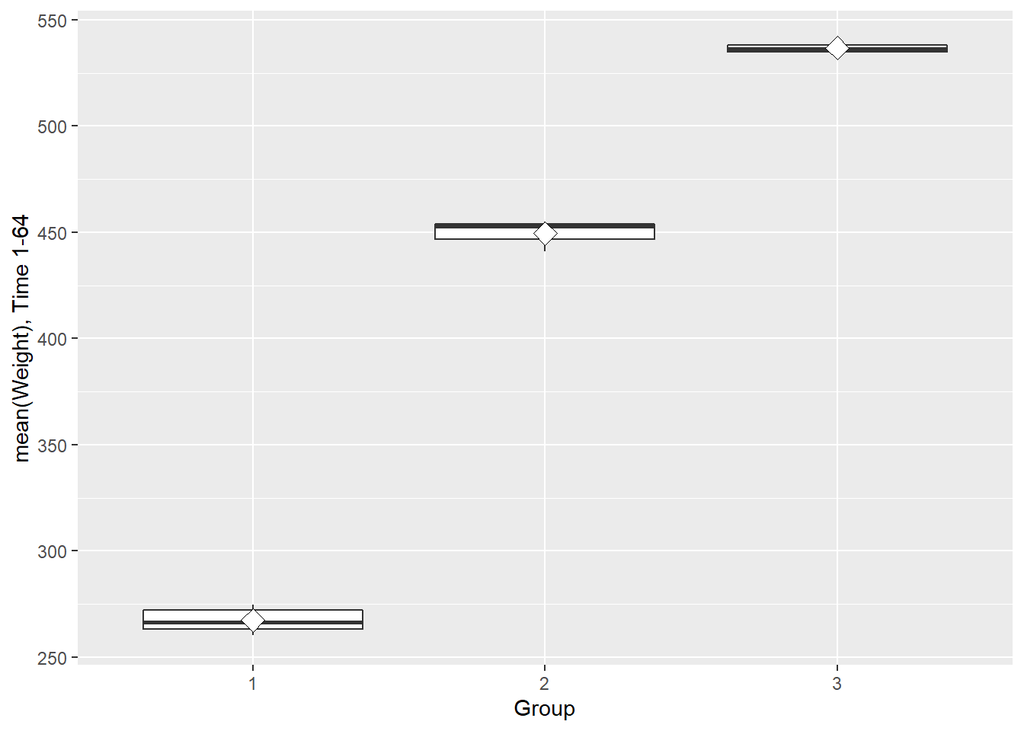

```r
ggplot(RATSL8S1, aes(x = Group, y = mean)) +
  geom_boxplot() +
  stat_summary(fun.y = "mean", geom = "point", shape=23, size=4, fill = "white") +
  scale_y_continuous(name = "mean(Weight), Time 1-64")
```

========================================================================================================== An outlier in each group was removed and the mean weight profiles were plotted again. Without outliers, the mean of the weight in group 2 and 3 seems higher than group 1. There seems to be an evidence of difference in location of the summary measure distributions in each group ==========================================================================================================

# 6.1.14 Adding the baseline from the original data as a new variable to the summary data

```r
RATSL8S2 <- RATSL8S %>%
  mutate(baseline = RATS$WD1)
```

# 6.1.15 Fitting the linear model with the mean as the response

```r
fit <- lm(mean ~ baseline + Group , data = RATSL8S2)
```

# 6.1.16 Computing the analysis of variance table for the fitted model with anova()

```r
anova(fit)
```

```
## Analysis of Variance Table
##
## Response: mean
##           Df Sum Sq Mean Sq   F value    Pr(>F)
## baseline   1 252125  252125 2237.0655 5.217e-15 ***
## Group      2    726     363    3.2219   0.07586 .
## Residuals 12   1352     113
## ---
## Signif. codes:  0 '***' 0.001 '**' 0.01 '*' 0.05 '.' 0.1 ' ' 1
```

=========================================================================================================== By incorporating the baseline values in to the summary measures data and performing ANOVA analysis, we can see that the baseline weight is strongly related to the weights observed after the intervention, but there seems to be no evidence of Group 2 and 3 gaining significantly more weight compared to Group 1 ===========================================================================================================

# 6.2.1 Reading the BPRS data

```r
BPRS <- read.table("https://raw.githubusercontent.com/KimmoVehkalahti/MABS/master/Examples/data/BPRS.txt", sep  =" ", header = T)
names(BPRS)
```

```
##  [1] "treatment" "subject"   "week0"     "week1"     "week2"
##  [6] "week3"     "week4"     "week5"     "week6"     "week7"
## [11] "week8"
```

```r
str(BPRS)
```

```
## 'data.frame':    40 obs. of  11 variables:
##  $ treatment: int  1 1 1 1 1 1 1 1 1 1 ...
##  $ subject  : int  1 2 3 4 5 6 7 8 9 10 ...
##  $ week0    : int  42 58 54 55 72 48 71 30 41 57 ...
##  $ week1    : int  36 68 55 77 75 43 61 36 43 51 ...
##  $ week2    : int  36 61 41 49 72 41 47 38 39 51 ...
##  $ week3    : int  43 55 38 54 65 38 30 38 35 55 ...
##  $ week4    : int  41 43 43 56 50 36 27 31 28 53 ...
##  $ week5    : int  40 34 28 50 39 29 40 26 22 43 ...
##  $ week6    : int  38 28 29 47 32 33 30 26 20 43 ...
##  $ week7    : int  47 28 25 42 38 27 31 25 23 39 ...
##  $ week8    : int  51 28 24 46 32 25 31 24 21 32 ...
```

```r
summary(BPRS)
```

```
##    treatment      subject          week0           week1
##  Min.   :1.0   Min.   : 1.00   Min.   :24.00   Min.   :23.00
##  1st Qu.:1.0   1st Qu.: 5.75   1st Qu.:38.00   1st Qu.:35.00
##  Median :1.5   Median :10.50   Median :46.00   Median :41.00
##  Mean   :1.5   Mean   :10.50   Mean   :48.00   Mean   :46.33
##  3rd Qu.:2.0   3rd Qu.:15.25   3rd Qu.:58.25   3rd Qu.:54.25
##  Max.   :2.0   Max.   :20.00   Max.   :78.00   Max.   :95.00
##      week2          week3           week4           week5
##  Min.   :26.0   Min.   :24.00   Min.   :20.00   Min.   :20.00
##  1st Qu.:32.0   1st Qu.:29.75   1st Qu.:28.00   1st Qu.:26.00
##  Median :38.0   Median :36.50   Median :34.50   Median :30.50
##  Mean   :41.7   Mean   :39.15   Mean   :36.35   Mean   :32.55
##  3rd Qu.:49.0   3rd Qu.:44.50   3rd Qu.:43.00   3rd Qu.:38.00
##  Max.   :75.0   Max.   :76.00   Max.   :66.00   Max.   :64.00
##      week6           week7          week8
##  Min.   :19.00   Min.   :18.0   Min.   :20.00
##  1st Qu.:22.75   1st Qu.:23.0   1st Qu.:22.75
##  Median :28.50   Median :30.0   Median :28.00
##  Mean   :31.23   Mean   :32.2   Mean   :31.43
##  3rd Qu.:37.00   3rd Qu.:38.0   3rd Qu.:35.25
##  Max.   :64.00   Max.   :62.0   Max.   :75.00
```

=========================================================== BPRS data contains 40 male subjects were randomly assigned to one of two treatment groups and each subject was rated on the brief psychiatric rating scale (BPRS) measured before treatment began (week 0) and then at weekly intervals for eight weeks. The BPRS assesses the level of 18 symptom constructs such as hostility, suspiciousness, hallucinations and grandiosity; each of these is rated from one (not present) to seven (extremely severe). The scale is used to evaluate patients suspected of having schizophrenia. ============================================================

# 6.2.2 Factoring the categorical variables in BPRS data

```r
BPRS$treatment <- factor(BPRS$treatment)
BPRS$subject <- factor(BPRS$subject)
```